# Food Consumption In Indonesia

#### After root transformation, it is seen that the residues do not have a normal distribution according to the shapiro-wilk test.

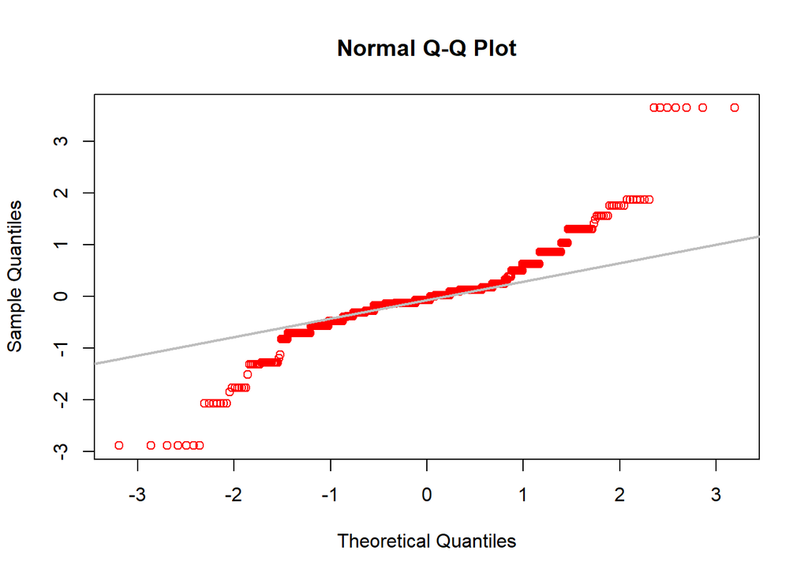

### It is clearly seen in the graph created from the distributions of the residuals that the residuals do not have a normal distribution.

### From all the resulting data we conclude that the residuals do not fit the normal distribution.

### $H_0$ is rejected

## Yeo-Johnson Transformation

### this function converts Box-Cox or Yeo-Johnson to each variable in a dataset

uses a re-weighted maximum likelihood (if robust = True) to fit solidly.

### if robust = False it uses nroaml ML method

```r
transfo_df <- transfo(df$`(C15) % MONTHLY EXPENDITURE FOR FOOD`, type = "YJ", robust = FALSE)
```

```
##
##  The input data has 710 rows and 1 columns.
```

```r
lambda <- transfo_df$lambdahats
lambda
```

```
## [1] 0.6534852
```

```r
df_yj <- transform(df, yj_count = df$`(C15) % MONTHLY EXPENDITURE FOR FOOD`^(lambda))
head(df_yj,10)
```

|  | X.B10..SOCIAL.CLAS | X.C15....MONTHLY.EXPENDITURE.FOR.FOOD | X.B7..EDUCATION.LEVEL | X.B9..OCCUPATION | X.A2..PROVINCE | X.B3..GENDER | X.B4..AGE | yj_count |
| --- | --- | --- | --- | --- | --- | --- | --- | --- |
| 1 | Lower Class | 57 | Senior High School | Private Employees | DKI Jakarta | Female | 31 | 14.042300 |
| 2 | Lower Class | 43 | Bachelor degree | Private Employees | DKI Jakarta | Female | 36 | 11.680125 |
| 3 | Middle Class | 38 | Senior High School | Private Employees | DKI Jakarta | Male | 24 | 10.773708 |
| 4 | Lower Class | 61 | Senior High School | Private Employees | DKI Jakarta | Female | 63 | 14.678668 |
| 5 | Lower Class | 58 | Primary School | Government Employees | DKI Jakarta | Male | 43 | 14.202805 |
| 6 | Lower Class | 34 | Senior High School | Government Employees | DKI Jakarta | Female | 47 | 10.018411 |
| 7 | Upper Class | 26 | Senior High School | Enterpreneur | DKI Jakarta | Female | 28 | 8.407447 |
| 8 | Lower Class | 57 | Senior High School | Enterpreneur | DKI Jakarta | Female | 48 | 14.042300 |
| 9 | Upper Class | 24 | Senior High School | Enterpreneur | DKI Jakarta | Female | 36 | 7.978985 |
| 10 | Upper Class | 27 | Bachelor degree | Private Employees | DKI Jakarta | Female | 39 | 8.617376 |

#### our lambda value is 0.6534852

### anova model after yj2 transformation

```r
df_yj_anova <- aov( df_yj$yj_count ~ df_yj$X.B10..SOCIAL.CLAS, data = df_yj )
summary(df_yj_anova)
```

```
##                           Df Sum Sq Mean Sq F value Pr(>F)
## df_yj$X.B10..SOCIAL.CLAS   2   4109  2054.6   602.6 <2e-16 ***
## Residuals                707   2411     3.4
## ---
## Signif. codes:  0 '***' 0.001 '**' 0.01 '*' 0.05 '.' 0.1 ' ' 1
```

If we interpret the result, $H_0$ is rejected in the anova model after the Transformation.

### Normality tests after transformation

```r
shapiro.test(df_yj_anova$residuals)
```

```
##
##  Shapiro-Wilk normality test
##
## data:  df_yj_anova$residuals
## W = 0.87933, p-value < 2.2e-16
```

```r
lillie.test(df_yj_anova$residuals)
```

```
##
##  Lilliefors (Kolmogorov-Smirnov) normality test
##
## data:  df_yj_anova$residuals
## D = 0.17557, p-value < 2.2e-16
```

#### According to the results obtained, it is seen that the residues are not normally distributed after the YJ change.

### Homogeneity of variances

```r
bartlett.test(df_yj$yj_count ~ df_yj$X.B10..SOCIAL.CLAS, data = df_yj )
```

```
##
##  Bartlett test of homogeneity of variances
##
## data:  df_yj$yj_count by df_yj$X.B10..SOCIAL.CLAS
## Bartlett's K-squared = 1.9121, df = 2, p-value = 0.3844
```